# fetal health classification project final

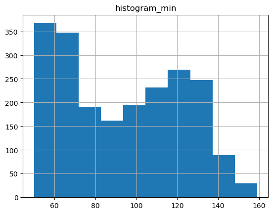

```python
data. histogram_min.hist()
plt.title('histogram_min')
```

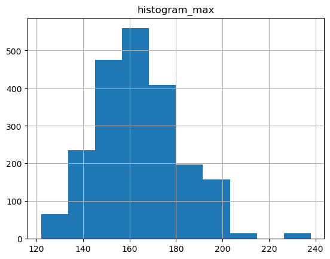

```python
data.histogram_max.hist()
plt.title('histogram_max')
```

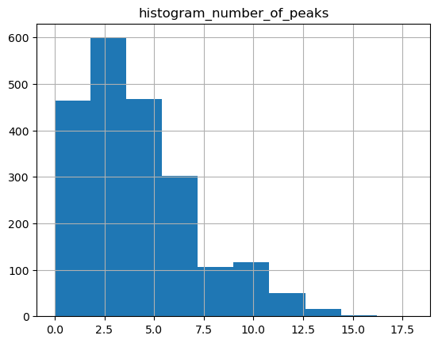

```python
data.histogram_number_of_peaks.hist()
plt.title('histogram_number_of_peaks')
```

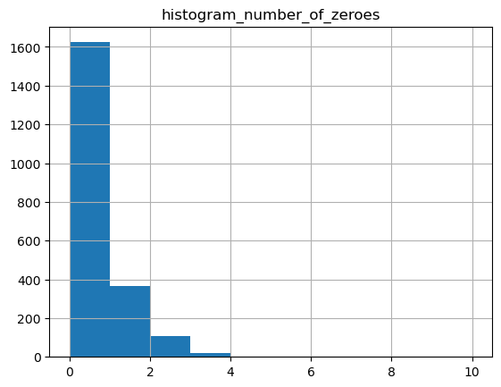

```python
data.histogram_number_of_zeroes.hist()
plt.title('histogram_number_of_zeroes')
```

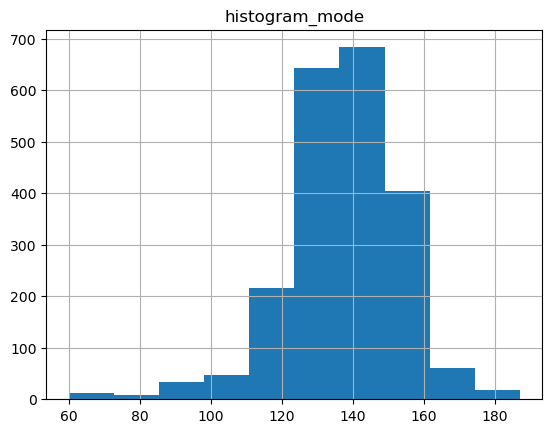

```python
data.histogram_mode.hist()
plt.title('histogram_mode')
```

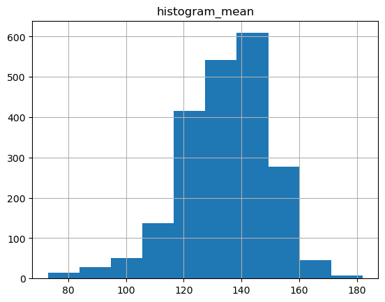

```python
data.histogram_mean.hist()
plt.title('histogram_mean')
```

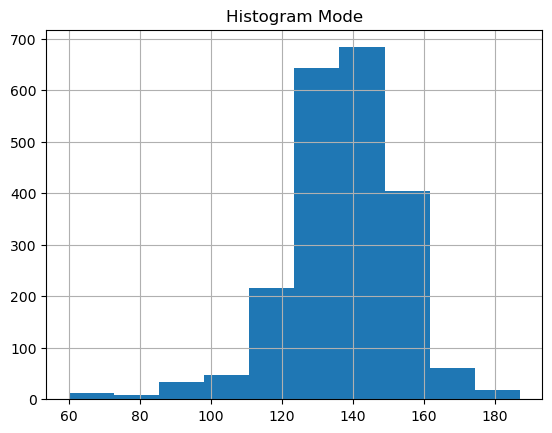

```python
data.histogram_mode.hist()
plt.title('Histogram Mode')
```

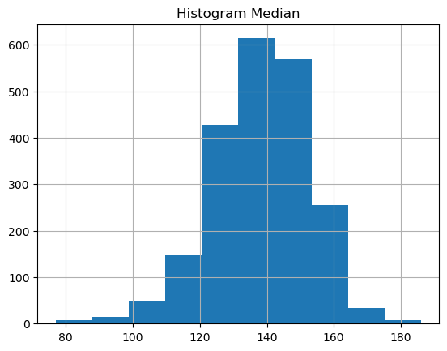

```python
data.histogram_median.hist()
plt.title('Histogram Median')
```

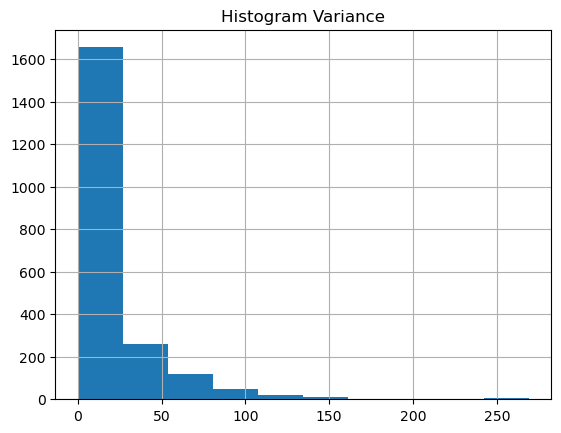

```python
data.histogram_variance.hist()
plt.title('Histogram Variance')
```

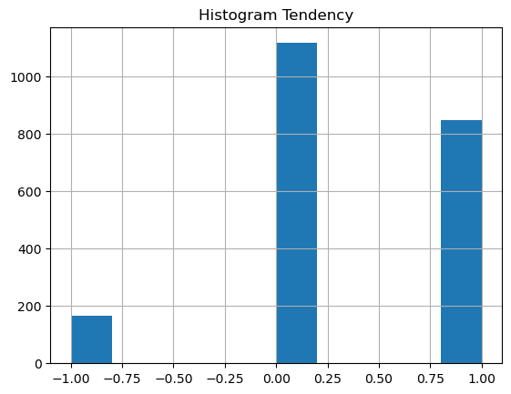

```python
data.histogram_tendency.hist()
plt.title('Histogram Tendency')
```

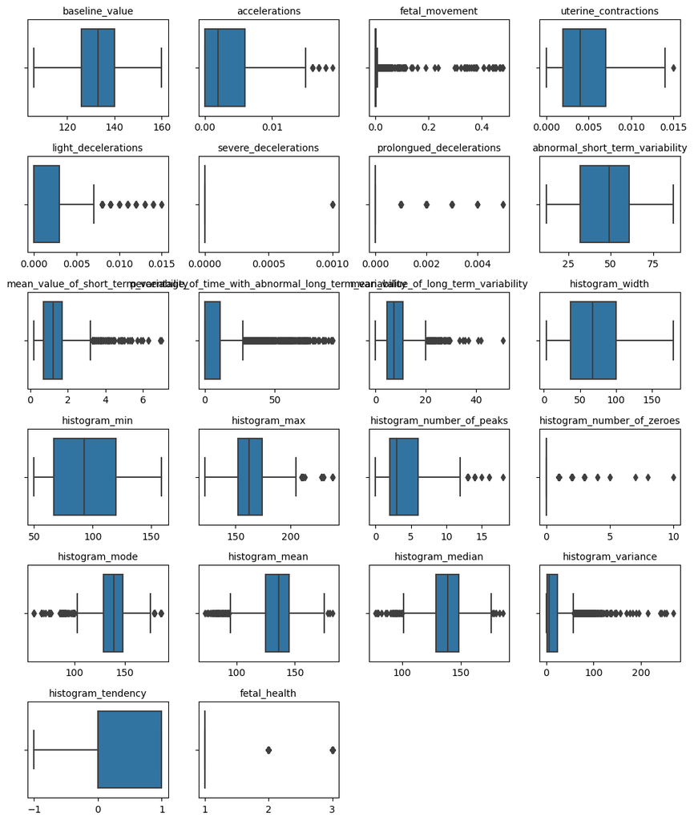

```python
fig, axes = plt.subplots(6, 4, figsize=(10, 12))
axes = axes.flatten()

# Create a boxplot for each continuous variable
for i, column in enumerate(data.columns):
    sns.boxplot(data=data, x=column, ax=axes[i])
    axes[i].set_title(f"{column}", fontsize=10)
    axes[i].set_xlabel("")  # Remove x-axis title

# Remove empty subplot
for i in range(len(data.columns), len(axes)):
    fig.delaxes(axes[i])

# Adjust layout
plt.tight_layout()
plt.show()
```

From the boxplot, we can see that many boxplot exhibits outliers.Moreover, the data was extracted and interepted by Experts.It is believed that these observation may not be outliers in the actual clinical tests. They could indicate of various factors, such as fetal distree,maternal condition. No action needed to be taken in the outliers.

```python
#correlation
data.corr()
```

|  | baseline_value | accelerations | fetal_movement | uterine_contractions | light_decelerations | severe_decelerations | prolongued_decelerations | abnormal_short_term_variability | mean_value_of_short_term_variability | percentage_of_time_with_abnormal_long_term_variability | mean_value_of_long_term_variability | histogram_width | histogram_min | histogram_max | histogram_number_of_peaks | histogram_number_of_zeroes | histogram_mode | histogram_mean | histogram_median | histogram_variance | histogram_tendency | fetal_health |
| --- | --- | --- | --- | --- | --- | --- | --- | --- | --- | --- | --- | --- | --- | --- | --- | --- | --- | --- | --- | --- | --- | --- |
| baseline_value | 1.000000 | -0.080560 | -0.033436 | -0.146373 | -0.159032 | -0.053518 | -0.104597 | 0.305570 | -0.279607 | 0.285630 | -0.032091 | -0.147679 | 0.361619 | 0.275110 | -0.113933 | -0.004745 | 0.708993 | 0.723121 | 0.789246 | -0.133938 | 0.293503 | 0.148151 |
| accelerations | -0.080560 | 1.000000 | 0.048235 | 0.089674 | -0.108615 | -0.043018 | -0.127749 | -0.279577 | 0.207170 | -0.373943 | -0.142363 | 0.298631 | -0.154286 | 0.394147 | 0.190452 | -0.006147 | 0.243610 | 0.270334 | 0.272849 | 0.125704 | 0.028420 | -0.364066 |
| fetal_movement | -0.033436 | 0.048235 | 1.000000 | -0.068779 | 0.049228 | -0.010976 | 0.265922 | -0.103715 | 0.121314 | -0.074096 | 0.011047 | 0.162790 | -0.153917 | 0.099853 | 0.164654 | -0.017749 | -0.061192 | -0.089671 | -0.072329 | 0.179340 | -0.001541 | 0.088010 |
| uterine_contractions | -0.146373 | 0.089674 | -0.068779 | 1.000000 | 0.285079 | 0.006788 | 0.077036 | -0.232811 | 0.289679 | -0.306608 | -0.066058 | 0.142541 | -0.113323 | 0.122766 | 0.082693 | 0.057894 | -0.104854 | -0.187505 | -0.140287 | 0.238582 | -0.072314 | -0.204894 |
| light_decelerations | -0.159032 | -0.108615 | 0.049228 | 0.285079 | 1.000000 | 0.107573 | 0.225611 | -0.119152 | 0.562170 | -0.271282 | -0.242932 | 0.520467 | -0.553534 | 0.218043 | 0.397620 | 0.235296 | -0.347233 | -0.527354 | -0.388586 | 0.564289 | 0.000072 | 0.058870 |
| severe_decelerations | -0.053518 | -0.043018 | -0.010976 | 0.006788 | 0.107573 | 1.000000 | 0.012395 | 0.033949 | 0.034130 | -0.030770 | -0.037667 | 0.044880 | -0.071974 | -0.021135 | 0.007024 | 0.043441 | -0.215161 | -0.158673 | -0.160451 | 0.136421 | -0.070483 | 0.131934 |
| prolongued_decelerations | -0.104597 | -0.127749 | 0.265922 | 0.077036 | 0.225611 | 0.012395 | 1.000000 | 0.046226 | 0.267011 | -0.137333 | -0.226514 | 0.265391 | -0.276764 | 0.120221 | 0.222860 | 0.056423 | -0.436416 | -0.488663 | -0.444778 | 0.503301 | -0.215405 | 0.484859 |
| abnormal_short_term_variability | 0.305570 | -0.279577 | -0.103715 | -0.232811 | -0.119152 | 0.033949 | 0.046226 | 1.000000 | -0.430705 | 0.459413 | -0.315105 | -0.260463 | 0.275378 | -0.111806 | -0.167561 | -0.149296 | 0.058363 | 0.074554 | 0.119960 | -0.146434 | -0.005748 | 0.471191 |
| mean_value_of_short_term_variability | -0.279607 | 0.207170 | 0.121314 | 0.289679 | 0.562170 | 0.034130 | 0.267011 | -0.430705 | 1.000000 | -0.470259 | 0.073892 | 0.660847 | -0.622569 | 0.409072 | 0.501430 | 0.266183 | -0.307586 | -0.445401 | -0.336109 | 0.555852 | -0.066140 | -0.103382 |
| percentage_of_time_with_abnormal_long_term_variability | 0.285630 | -0.373943 | -0.074096 | -0.306608 | -0.271282 | -0.030770 | -0.137333 | 0.459413 | -0.470259 | 1.000000 | -0.171114 | -0.451297 | 0.422834 | -0.283183 | -0.279301 | -0.121784 | 0.165211 | 0.222321 | 0.186480 | -0.281536 | 0.042481 | 0.426146 |
| mean_value_of_long_term_variability | -0.032091 | -0.142363 | 0.011047 | -0.066058 | -0.242932 | -0.037667 | -0.226514 | -0.315105 | 0.073892 | -0.171114 | 1.000000 | 0.110942 | -0.144976 | 0.002023 | 0.056357 | 0.123869 | 0.072071 | 0.137813 | 0.063228 | -0.164079 | 0.153093 | -0.226797 |
| histogram_width | -0.147679 | 0.298631 | 0.162790 | 0.142541 | 0.520467 | 0.044880 | 0.265391 | -0.260463 | 0.660847 | -0.451297 | 0.110942 | 1.000000 | -0.898519 | 0.690769 | 0.747071 | 0.317276 | -0.159261 | -0.280846 | -0.168854 | 0.615884 | 0.118152 | -0.068789 |
| histogram_min | 0.361619 | -0.154286 | -0.153917 | -0.113323 | -0.553534 | -0.071974 | -0.276764 | 0.275378 | -0.622569 | 0.422834 | -0.144976 | -0.898519 | 1.000000 | -0.303286 | -0.670287 | -0.306567 | 0.353067 | 0.486121 | 0.400191 | -0.545091 | -0.242579 | 0.063175 |
| histogram_max | 0.275110 | 0.394147 | 0.099853 | 0.122766 | 0.218043 | -0.021135 | 0.120221 | -0.111806 | 0.409072 | -0.283183 | 0.002023 | 0.690769 | -0.303286 | 1.000000 | 0.517652 | 0.183766 | 0.235877 | 0.191108 | 0.292680 | 0.439094 | -0.143111 | -0.045265 |
| histogram_number_of_peaks | -0.113933 | 0.190452 | 0.164654 | 0.082693 | 0.397620 | 0.007024 | 0.222860 | -0.167561 | 0.501430 | -0.279301 | 0.056357 | 0.747071 | -0.670287 | 0.517652 | 1.000000 | 0.288593 | -0.100123 | -0.217242 | -0.122844 | 0.454354 | 0.110114 | -0.023666 |
| histogram_number_of_zeroes | -0.004745 | -0.006147 | -0.017749 | 0.057894 | 0.235296 | 0.043441 | 0.056423 | -0.149296 | 0.266183 | -0.121784 | 0.123869 | 0.317276 | -0.306567 | 0.183766 | 0.288593 | 1.000000 | -0.057978 | -0.084417 | -0.052896 | 0.196747 | 0.084694 | -0.016682 |
| histogram_mode | 0.708993 | 0.243610 | -0.061192 | -0.104854 | -0.347233 | -0.215161 | -0.436416 | 0.058363 | -0.307586 | 0.165211 | 0.072071 | -0.159261 | 0.353067 | 0.235877 | -0.100123 | -0.057978 | 1.000000 | 0.893412 | 0.933399 | -0.312765 | 0.415564 | -0.250412 |
| histogram_mean | 0.723121 | 0.270334 | -0.089671 | -0.187505 | -0.527354 | -0.158673 | -0.488663 | 0.074554 | -0.445401 | 0.222321 | 0.137813 | -0.280846 | 0.486121 | 0.191108 | -0.217242 | -0.084417 | 0.893412 | 1.000000 | 0.948251 | -0.399423 | 0.327076 | -0.226985 |
| histogram_median | 0.789246 | 0.272849 | -0.072329 | -0.140287 | -0.388586 | -0.160451 | -0.444778 | 0.119960 | -0.336109 | 0.186480 | 0.063228 | -0.168854 | 0.400191 | 0.292680 | -0.122844 | -0.052896 | 0.933399 | 0.948251 | 1.000000 | -0.294105 | 0.389210 | -0.205033 |
| histogram_variance | -0.133938 | 0.125704 | 0.179340 | 0.238582 | 0.564289 | 0.136421 | 0.503301 | -0.146434 | 0.555852 | -0.281536 | -0.164079 | 0.615884 | -0.545091 | 0.439094 | 0.454354 | 0.196747 | -0.312765 | -0.399423 | -0.294105 | 1.000000 | -0.078013 | 0.206630 |
| histogram_tendency | 0.293503 | 0.028420 | -0.001541 | -0.072314 | 0.000072 | -0.070483 | -0.215405 | -0.005748 | -0.066140 | 0.042481 | 0.153093 | 0.118152 | -0.242579 | -0.143111 | 0.110114 | 0.084694 | 0.415564 | 0.327076 | 0.389210 | -0.078013 | 1.000000 | -0.131976 |
| fetal_health | 0.148151 | -0.364066 | 0.088010 | -0.204894 | 0.058870 | 0.131934 | 0.484859 | 0.471191 | -0.103382 | 0.426146 | -0.226797 | -0.068789 | 0.063175 | -0.045265 | -0.023666 | -0.016682 | -0.250412 | -0.226985 | -0.205033 | 0.206630 | -0.131976 | 1.000000 |

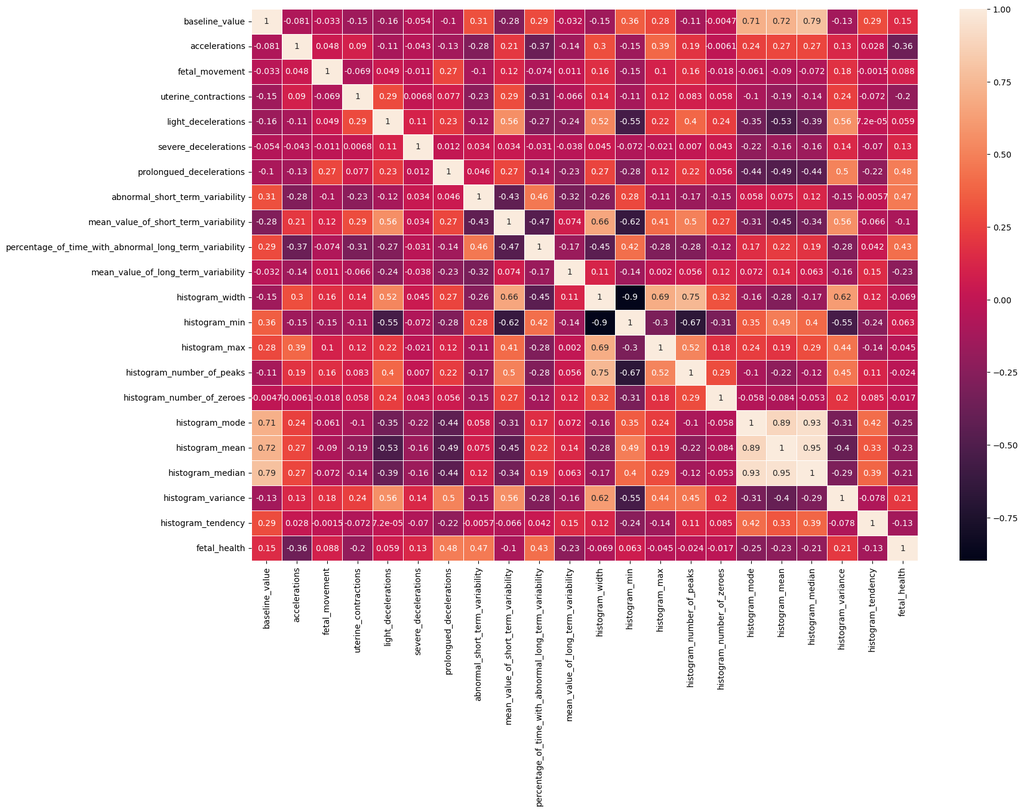

```python
# Set the size of figure to 12 by 10.
plt.figure(figsize=(18,12))
sns.heatmap(data.corr(),annot=True,linewidth=.5)
```

```python
def highly_corr(data):


    df2 = data.corr()

    df1 = pd.DataFrame(df2.unstack(),columns=['corr_value'])

    filtered_df = pd.DataFrame(df1[((df1['corr_value'] >= .5) | (df1['corr_value'] <= -.5)) & (df1['corr_value'] !=1.000)])


    filtered_df.reset_index(inplace=True)

    filtered_df.sort_values(by='corr_value',ascending=False,inplace=True)
    filtered_df.drop_duplicates(inplace=True,subset='corr_value',keep='first')

    print("Correlation values of highly correlated columns")

    return filtered_df
```

```python
highly_corr(data)
```

```
Correlation values of highly correlated columns
```

|  | level_0 | level_1 | corr_value |
| --- | --- | --- | --- |
| 37 | histogram_mean | histogram_median | 0.948251 |
| 33 | histogram_mode | histogram_median | 0.933399 |
| 36 | histogram_mean | histogram_mode | 0.893412 |
| 2 | baseline_value | histogram_median | 0.789246 |
| 18 | histogram_width | histogram_number_of_peaks | 0.747071 |
| 34 | histogram_mean | baseline_value | 0.723121 |
| 31 | histogram_mode | baseline_value | 0.708993 |
| 25 | histogram_max | histogram_width | 0.690769 |
| 10 | mean_value_of_short_term_variability | histogram_width | 0.660847 |
| 19 | histogram_width | histogram_variance | 0.615884 |
| 7 | light_decelerations | histogram_variance | 0.564289 |
| 3 | light_decelerations | mean_value_of_short_term_variability | 0.562170 |
| 13 | mean_value_of_short_term_variability | histogram_variance | 0.555852 |
| 4 | light_decelerations | histogram_width | 0.520467 |
| 30 | histogram_number_of_peaks | histogram_max | 0.517652 |
| 8 | prolongued_decelerations | histogram_variance | 0.503301 |
| 27 | histogram_number_of_peaks | mean_value_of_short_term_variability | 0.501430 |
| 6 | light_decelerations | histogram_mean | -0.527354 |
| 45 | histogram_variance | histogram_min | -0.545091 |
| 20 | histogram_min | light_decelerations | -0.553534 |
| 21 | histogram_min | mean_value_of_short_term_variability | -0.622569 |
| 29 | histogram_number_of_peaks | histogram_min | -0.670287 |
| 22 | histogram_min | histogram_width | -0.898519 |

From the observation,we can see that the histogram mean , histogram mode, histogram median are highly correlated with each other and it positive correlation For negative correlation, we can see that histogram_min and histogram width are highly correlated.

```python
#Finding the correlation with the predictor and the target value

data.corr()['fetal_health'].sort_values(ascending=False)
```

```
fetal_health                                              1.000000
prolongued_decelerations                                  0.484859
abnormal_short_term_variability                           0.471191
percentage_of_time_with_abnormal_long_term_variability    0.426146
histogram_variance                                        0.206630
baseline_value                                            0.148151
severe_decelerations                                      0.131934
fetal_movement                                            0.088010
histogram_min                                             0.063175
light_decelerations                                       0.058870
histogram_number_of_zeroes                               -0.016682
histogram_number_of_peaks                                -0.023666
histogram_max                                            -0.045265
histogram_width                                          -0.068789
mean_value_of_short_term_variability                     -0.103382
histogram_tendency                                       -0.131976
uterine_contractions                                     -0.204894
histogram_median                                         -0.205033
mean_value_of_long_term_variability                      -0.226797
histogram_mean                                           -0.226985
histogram_mode                                           -0.250412
accelerations                                            -0.364066
Name: fetal_health, dtype: float64
```

prolongued_decelerations 0.484859 abnormal_short_term_variability 0.471191 percentage_of_time_with_abnormal_long_term_variability 0.426146 These are positively correlated with fetal health.

The correlation which are below <0.1 are considered as no correlation

```python
hist_column = []
kde_column = []
```

```python
for i in data.columns:
    if len(data[i].value_counts()) < 10:
        hist_column.append(i)
        print("--------")
        print(i,"-> number of distinct value :",len(data[i].value_counts()))
        print(data[i].value_counts(ascending=False,normalize=True)*100)
        print()
    else:
        kde_column.append(i)
        print(i,"-> number of distinct value :",len(data[i].value_counts()))
        print()
```

```
baseline_value -> number of distinct value : 48

accelerations -> number of distinct value : 20

fetal_movement -> number of distinct value : 102

uterine_contractions -> number of distinct value : 16

light_decelerations -> number of distinct value : 16

--------
severe_decelerations -> number of distinct value : 2
0.000    99.670743
0.001     0.329257
Name: severe_decelerations, dtype: float64

--------
prolongued_decelerations -> number of distinct value : 6
0.000    91.627469
0.002     3.386642
0.001     3.292568
0.003     1.128881
0.004     0.423330
0.005     0.141110
Name: prolongued_decelerations, dtype: float64

abnormal_short_term_variability -> number of distinct value : 75

mean_value_of_short_term_variability -> number of distinct value : 57

percentage_of_time_with_abnormal_long_term_variability -> number of distinct value : 87

mean_value_of_long_term_variability -> number of distinct value : 249

histogram_width -> number of distinct value : 154

histogram_min -> number of distinct value : 109

histogram_max -> number of distinct value : 86

```

[output cut: 21 more lines]

```
histogram_variance -> number of distinct value : 133

--------
histogram_tendency -> number of distinct value : 3
 0.0    52.445908
 1.0    39.793039
-1.0     7.761054
Name: histogram_tendency, dtype: float64

--------
fetal_health -> number of distinct value : 3
1.0    77.845720
2.0    13.875823
3.0     8.278457
Name: fetal_health, dtype: float64
```

```python
data[['severe_decelerations','fetal_health']].value_counts(normalize=True)
```

```
severe_decelerations  fetal_health
0.000                 1.0             0.777987
                      2.0             0.138758
                      3.0             0.079962
0.001                 3.0             0.002822
                      1.0             0.000470
dtype: float64
```

```python
data[['prolongued_decelerations','fetal_health']].value_counts(normalize=True)
```

```
prolongued_decelerations  fetal_health
0.000                     1.0             0.746002
                          2.0             0.131703
                          3.0             0.038570
0.001                     1.0             0.025400
0.002                     3.0             0.023989
0.003                     3.0             0.009407
0.002                     1.0             0.006585
0.001                     3.0             0.005174
0.004                     3.0             0.004233
0.002                     2.0             0.003293
0.001                     2.0             0.002352
0.003                     2.0             0.001411
0.005                     3.0             0.001411
0.003                     1.0             0.000470
dtype: float64
```

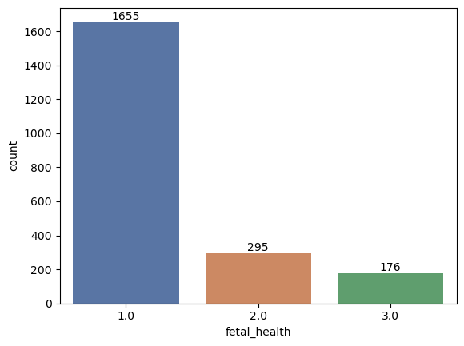

```python
ax = sns.countplot(data=data, x = 'fetal_health',palette='deep')
ax.bar_label(ax.containers[0])
plt.show()
```

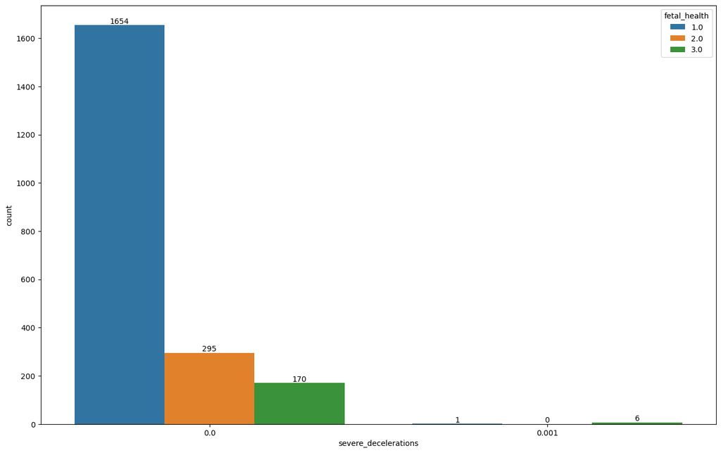

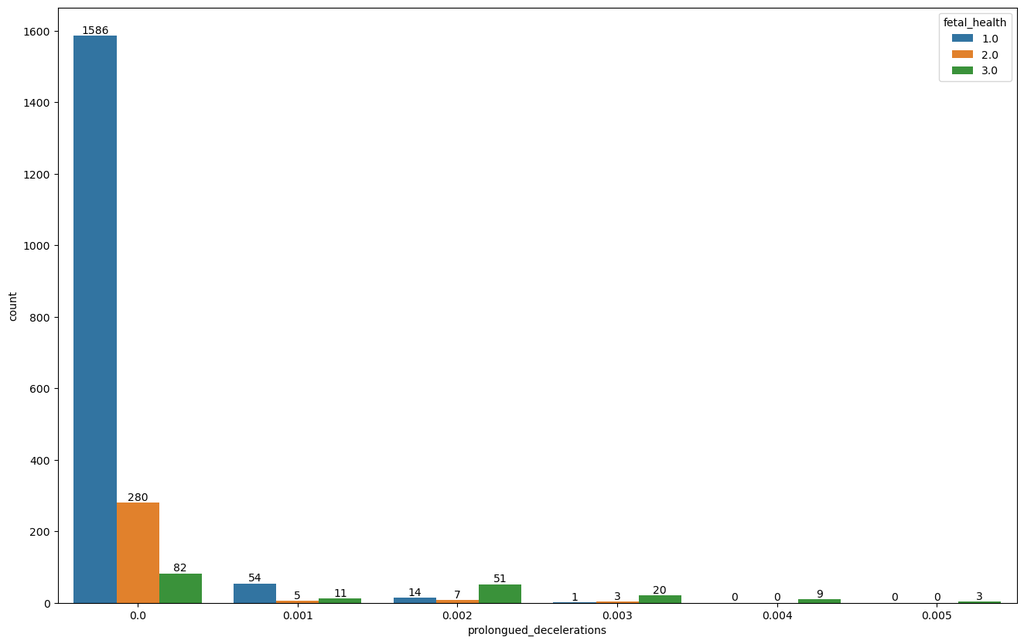

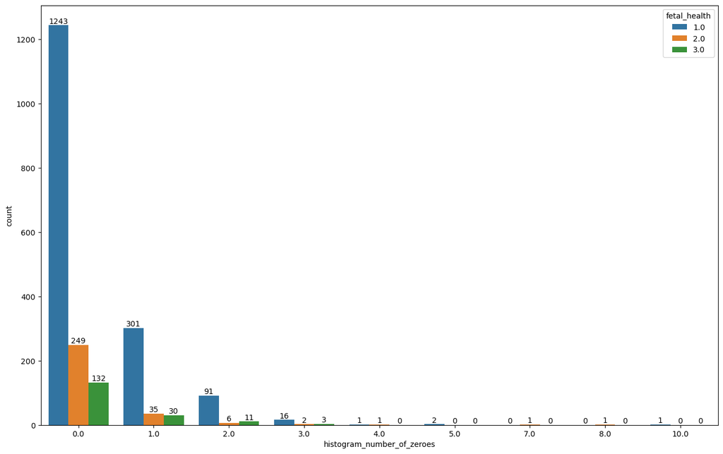

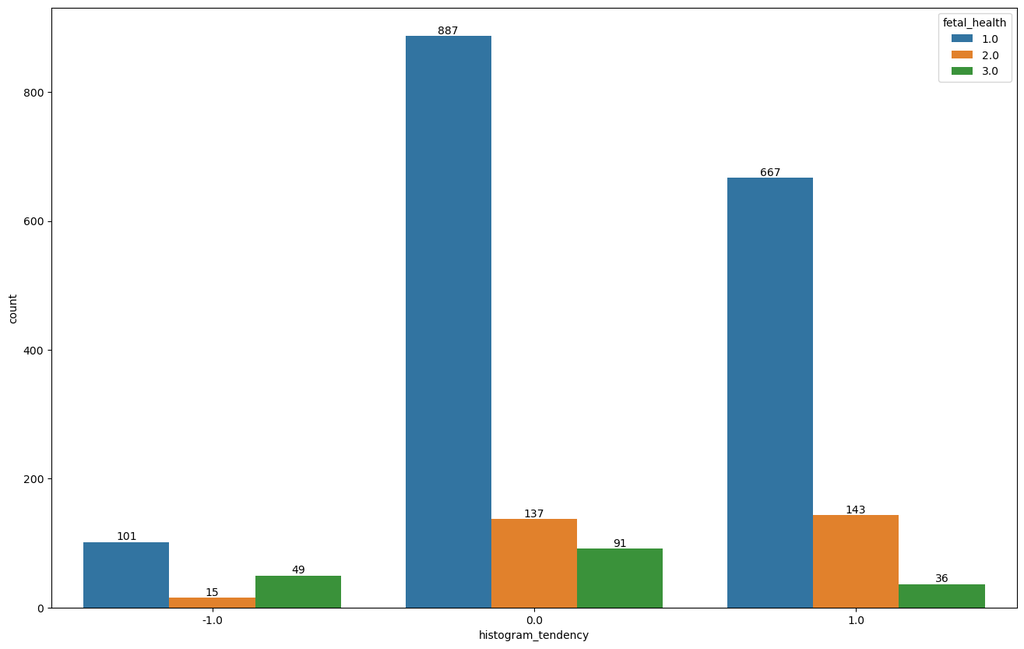

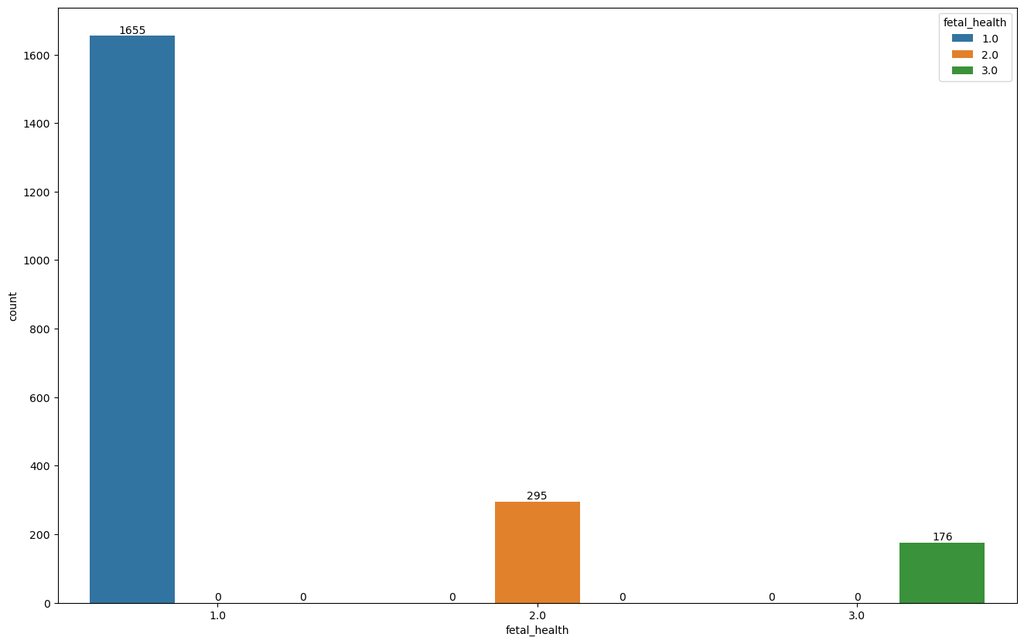

```python
#now we are gonna visualize the value  which belongs to which label based on the fetal health column
for i in hist_column:
    plt.figure(figsize=(16,10))
    ax = sns.countplot(data=data, x = i,hue='fetal_health')
    ax.bar_label(ax.containers[0])
    ax.bar_label(ax.containers[1])
    ax.bar_label(ax.containers[2])
    plt.show()
    print()
```